# Placenta Analysis 2

Ilya Kukovitskiy

July 2, 2018

```r
set.seed(1)
library(tree)
library(randomForest)
library(gbm)
library(ggplot2)
library(tree)
library("fitdistrplus")
library(tibble)
```

# NYMH x10 and x20

## Data Preprocessing

#### Reading in and storing datasets from file

```r
d10 <- read.csv('HemosiderinStatistics_NYMH_10x.csv')
d20 <- read.csv('HemosiderinStatistics_NYMH_20x.csv')
```

#### Seems like there’s an entry in d10 that’s not in d20: #17

```r
# Removing row 17:
d10 <- d10[-17,]
```

#### Seems like there’s a variable in d10 that’s not in d20: ‘Total Stain’

```r
# Recreating the column, which is the sum of Area_StainArtifact and Area_Hemosederin
d20 <- add_column(d20, Total.Stain = d20$Area_StainArtifact.sqmm. + d20$Area_Hemosiderin.sqmm., .after = 'Area_Hemosiderin.sqmm.')
```

## Data Analysis

### Viewing Data

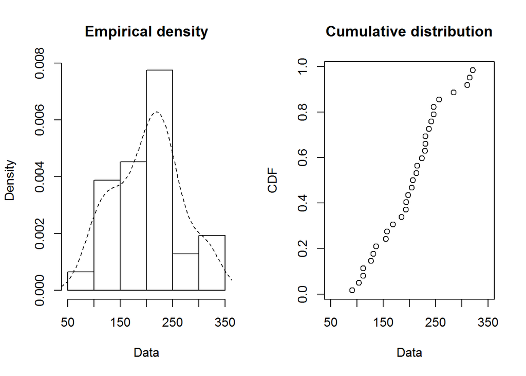

```r
# Viewing distribution

#for(i in 2:10){
#  plotdist(d10[,i], histo = TRUE, demp = TRUE)
#}
# Viewing Cullen and Fray graph
#for(i in 2:10){
#  descdist(d10[,i])
#}

# Viewing trouble variable
# 10
plotdist(d10$TotalVilliArea.sqmm., histo = TRUE, demp = TRUE)
```

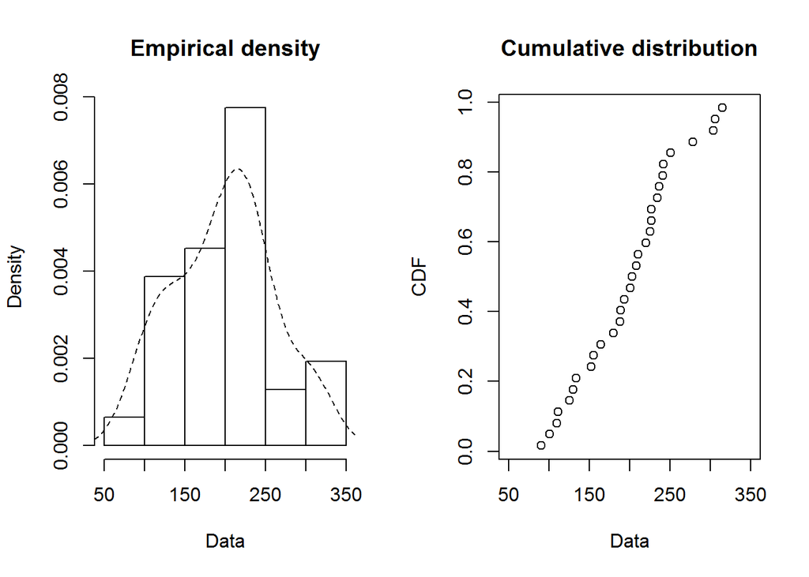

```r
# 20
plotdist(d20$TotalVilliArea.sqmm., histo = TRUE, demp = TRUE)
```

```r
# Means and Standard Deviations
# 10
print("The mean and sd for x10 are:")
```

```
## [1] "The mean and sd for x10 are:"
```

```r
mean(d10$TotalVilliArea.sqmm.)
```

```
## [1] 202.6577
```

```r
sd(d10$TotalVilliArea.sqmm.)
```

```
## [1] 62.59358
```

```r
# 20
print("The mean and sd for x20 are:")
```

```
## [1] "The mean and sd for x20 are:"
```

```r
mean(d20$TotalVilliArea.sqmm.)
```

```
## [1] 198.5482
```

```r
sd(d20$TotalVilliArea.sqmm.)
```

```
## [1] 60.9819
```

At first I was running to check distributions rather than assume that it is normal, to disprove the t-test. However, upon looking at the variable in question, the means are exactly 4 apart, with similar standard deviations, and almost identical distributions.

Another Idea: Pixel count is essentially double-integration. Theoretically, depending on the pixel counting algorithm, a refinement can increase all values by some amount. Research this? If there was such an effect, MOST if not ALL differences would be the same sign.

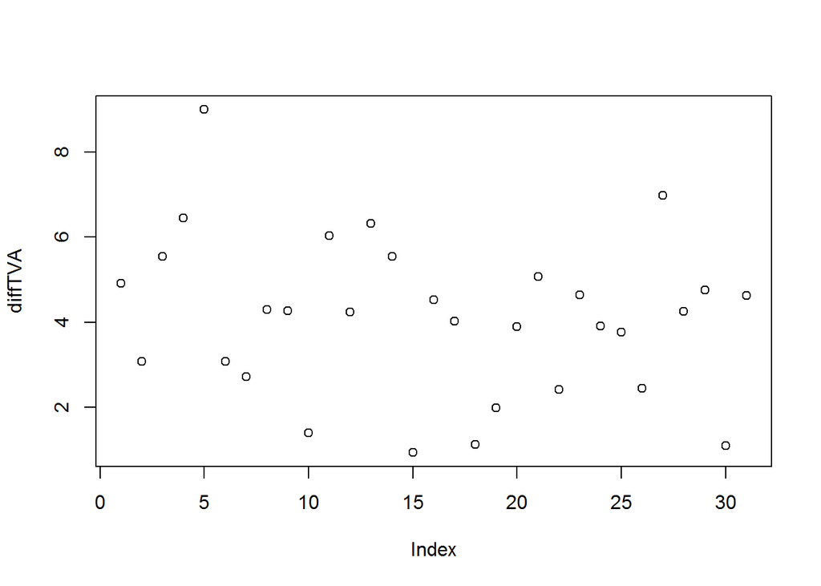

```r
diffTVA <- d10$TotalVilliArea.sqmm. - d20$TotalVilliArea.sqmm.
plot(diffTVA)
```

```r
# These are all positive!
```

```r
### Check Distribution of Data


## fitdist
# Fitting weibull and normal distribution

#fit.weibull <- fitdist(d10[,2], "weibull")
#fit.norm <- fitdist(d10[,2], "norm")

# Plotting fits

#plot(fit.weibull)
#plot(fit.norm)


#Weibull distribution fits the column a bit better than Normal distribution.
```

There are over 30 paired observations, allowing for use of the t-test under the assumption of normal distribution.

#### Creating matrix to record t.test results

```r
A_ttest <- matrix(c("",""),
                    nrow=1,
                    ncol=4)
colnames(A_ttest) <- c("Variable","t-stat","p-value","estimated mean of differences")
```

#### Performing and recording t-test for each variable

```r
for(i in 2:ncol(d20)){
  I<-i
  X<-t.test(d10[,I],d20[,I],paired = TRUE)
  A_ttest <- rbind(A_ttest,c(colnames(d10)[I],X[c(1,3,5)]))
}
```

#### Cleaning and looking at matrix

```r
# removing first row
A_ttest <- A_ttest[-1,]

# organizing matrix by p-value (statistical significance)
A_ttest <- A_ttest[order(as.numeric(A_ttest[,3]),decreasing=FALSE),]

# looking at matrix
A_ttest
```

```
##       Variable                   t-stat    p-value
##  [1,] "VPD"                      19.11772  2.374732e-18
##  [2,] "TotalVilliArea.sqmm."     12.35376  2.690638e-13
##  [3,] "Area_StainArtifact.sqmm." -8.447142 1.993532e-09
##  [4,] "Stain.2k"                 -6.587334 2.734825e-07
##  [5,] "Total.Stain"              -6.497419 3.502885e-07
##  [6,] "TotalTissueArea.sqmm."    4.874016  3.324392e-05
##  [7,] "Area_Hemosiderin.sqmm."   -4.277901 0.0001770125
##  [8,] "Stain2k.5k"               1.387645  0.175467
##  [9,] "Stain.10k"                0.7747713 0.4445388
## [10,] "Stain5k.10k"              0.2406466 0.811466
##       estimated mean of differences
##  [1,] 0.01481526
##  [2,] 4.109518
##  [3,] -0.02191122
##  [4,] -0.05886193
##  [5,] -0.05838531
##  [6,] 0.1262874
##  [7,] -0.03647409
##  [8,] 0.0003103584
##  [9,] 0.0001267048
## [10,] 3.956097e-05
```

#### Removing non-statistically significant variables

The null hypothesis is that there is no change between the variables of the first (x10) set and the second (x20) set of data. With a p-value of .05 or less, this null hypothesis is rejected, concluding that there was a consistent change between them.

t-test measures t-value, if t=0, null hypothesis is confirmed. The distance from 0 to determine statistical significance is given by the p-value. Generally, a p-value of .05 is used. The difference between means of the columns is given by mean of differences.

```r
# removing the cases where p>.05 and the null hypothesis cannot be rejected
# these remaining variables are different between the two datasets.
A_ttest <- A_ttest[A_ttest[,3]<0.05,]
A_ttest
```

```
##      Variable                   t-stat    p-value
## [1,] "VPD"                      19.11772  2.374732e-18
## [2,] "TotalVilliArea.sqmm."     12.35376  2.690638e-13
## [3,] "Area_StainArtifact.sqmm." -8.447142 1.993532e-09
## [4,] "Stain.2k"                 -6.587334 2.734825e-07
## [5,] "Total.Stain"              -6.497419 3.502885e-07
## [6,] "TotalTissueArea.sqmm."    4.874016  3.324392e-05
## [7,] "Area_Hemosiderin.sqmm."   -4.277901 0.0001770125
##      estimated mean of differences
## [1,] 0.01481526
## [2,] 4.109518
## [3,] -0.02191122
## [4,] -0.05886193
## [5,] -0.05838531
## [6,] 0.1262874
## [7,] -0.03647409
```

## Conclusion

Several variables differ between the x10 and x20 magnifications of the NYMH Hemosederin stains. Interpretation of estimates is left to consulting.

# NYMH and EARLI

## Data Preprocessing

#### Reading in and storing datasets from file

```r
e <- read.csv('HemosiderinStatistics_EARLI_20x.csv')
n <- read.csv('HemosiderinStatistics_NYMH_20x.csv')
e <- na.omit(e) #no omits!
n <- na.omit(n) #no omits!
```

#### Seems like there’s a variable in e that’s not in n: ‘Total Stain’

```r
colnames(e) #7
```

```
##  [1] "scene_name"               "TotalTissueArea.sqmm."
##  [3] "TotalVilliArea.sqmm."     "VPD"
##  [5] "Area_StainArtifact.sqmm." "Area_Hemosiderin.sqmm."
##  [7] "Total.Stain"              "Stain.10k"
##  [9] "Stain5k.10k"              "Stain2k.5k"
## [11] "Stain.2k"
```

```r
colnames(n)
```

```
##  [1] "scene_name"               "TotalTissueArea.sqmm."
##  [3] "TotalVilliArea.sqmm."     "VPD"
##  [5] "Area_StainArtifact.sqmm." "Area_Hemosiderin.sqmm."
##  [7] "Stain.10k"                "Stain5k.10k"
##  [9] "Stain2k.5k"               "Stain.2k"
```

```r
# Removing that column:
e <- e[,-7]
```

## Data Analysis

#### Creating matrix to record t.test results

```r
A_ttest <- matrix(c("",""),
                    nrow=1,
                    ncol=4)
colnames(A_ttest) <- c("Variable","t-stat","p-value","estimated mean of differences")
```

#### Performing and recording t-test for each variable

```r
for(i in 2:ncol(d20)){
  I<-i
  X<-t.test(d10[,I],d20[,I],paired = FALSE)
  A_ttest <- rbind(A_ttest,c(colnames(d10)[I],X[c(1,3,5)]))
}
```

#### Cleaning and looking at matrix

```r
# removing first row
A_ttest <- A_ttest[-1,]

# organizing matrix by p-value (statistical significance)
A_ttest <- A_ttest[order(as.numeric(A_ttest[,3]),decreasing=FALSE),]

# looking at matrix
A_ttest
```

```
##       Variable                   t-stat      p-value
##  [1,] "Area_StainArtifact.sqmm." -3.772265   0.0004570852
##  [2,] "Stain.2k"                 -1.742414   0.0868923
##  [3,] "Total.Stain"              -1.411266   0.1634676
##  [4,] "Area_Hemosiderin.sqmm."   -0.9647476  0.3386152
##  [5,] "VPD"                      0.7464617   0.4583036
##  [6,] "TotalVilliArea.sqmm."     0.2618289   0.7943508
##  [7,] "Stain2k.5k"               0.05855961  0.9534977
##  [8,] "Stain.10k"                0.03298798  0.9737938
##  [9,] "Stain5k.10k"              0.01093547  0.9913112
## [10,] "TotalTissueArea.sqmm."    0.005770525 0.995415
##       estimated mean of differences
##  [1,] Numeric,2
##  [2,] Numeric,2
##  [3,] Numeric,2
##  [4,] Numeric,2
##  [5,] Numeric,2
##  [6,] Numeric,2
##  [7,] Numeric,2
##  [8,] Numeric,2
##  [9,] Numeric,2
## [10,] Numeric,2
```

#### Removing non-statistically significant variables

The null hypothesis is that there is no change between the variables of the first (x10) set and the second (x20) set of data. With a p-value of .05 or less, this null hypothesis is rejected, concluding that there was a consistent change between them.

t-test measures t-value, if t=0, null hypothesis is confirmed. The distance from 0 to determine statistical significance is given by the p-value. Generally, a p-value of .05 is used. The difference between means of the columns is given by mean of differences.

```r
# removing the cases where p>.05 and the null hypothesis cannot be rejected
# these remaining variables are different between the two datasets.
A_ttest <- A_ttest[A_ttest[,3]<0.05,]
A_ttest
```

```
## $Variable
## [1] "Area_StainArtifact.sqmm."
##
## $`t-stat`
##         t
## -3.772265
##
## $`p-value`
## [1] 0.0004570852
##
## $`estimated mean of differences`
##  mean of x  mean of y
## 0.01431821 0.03622943
```

## Conclusion

### To improve this, I will try to predict whether an observation belongs to EARLI or NYMH.

#### Adding Variable and Combining datasets

```r
e <- cbind(e,rep(1,nrow(e)))
n <- cbind(n,rep(0,nrow(n)))
colnames(e)[11] <- colnames(n)[11] <- 'EARLI'
df <- rbind(e,n)
attach(df)
```

#### Simple Logistic Regression

```r
#initial logistic regression
glm <- glm(EARLI~., data=df, family='binomial')
```

#### The algorithm didn’t work without training/test set split. It seems like there aren’t enough observations of NYMH data to make a logistic regression model.

#### Simple Decision Tree

```r
#tree() can only handle 32 levels on factor predictors

names(Filter(is.factor, df)) #taking a look at which variables have factors -
```

```
## [1] "scene_name"
```

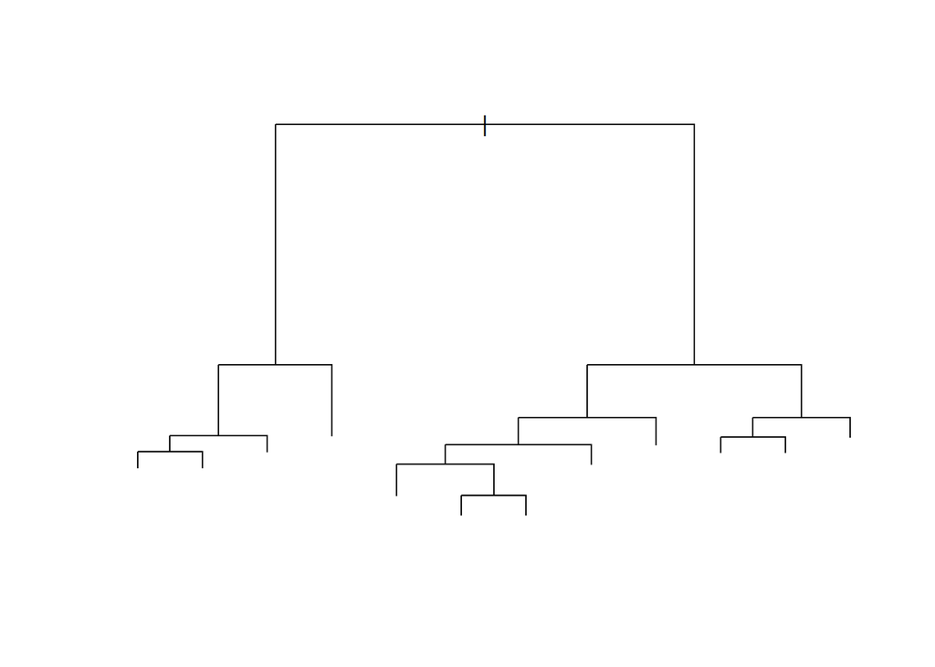

```r
#nlevels(scene_name) #scene_name has 811 levels - too many to grow trees on
View(scene_name) #just names of trials - removing this variable
#colnames(df)
df <- df[,-1]

#initial decision tree
tree <- tree(EARLI~., data=df)
#Plotting Tree
plot(tree)
```

```r
##
#View(tree)
#View(tree$frame)

#tree.pred <- predict(tree, type="class")
```